# A Reanalysis of Fosse and Winship (2019)

For details on these results, see [this working paper](https://osf.io/preprints/socarxiv/xrbgv/).

## Load packages and data

```r
library("dplyr")
library("ggplot2")
library("texreg")
library("weightedcontrasts")

library("apcR") # for wordsum data (get here: https://scholar.harvard.edu/apc/software-0)
data("wordsum")
d <- as_tibble(wordsum)
```

## Define helper functions

The first helper function extracts the non-linear effects from the model, while the second function computes a total (linear and non-linear) effect. The third function simply constructs a data frame from given age, period, and cohort effects, and is used for plotting.

```r
get_deviations_w_intercept <- function(model, set, contrasts) {
    extract_coefs <- coef(model)[grepl(set, names(coef(model)))]
    extract_coefs <- extract_coefs[2:length(extract_coefs)]
    extract_coefs[is.na(extract_coefs)] <- 0
    deviations <- contrasts[, 2:(1 + length(extract_coefs))] %*% extract_coefs
    coef(model)[1] + deviations[, 1]
}

get_total_effect <- function(contrasts, linear_coef, nonlinear_coefs) {
    linear_contrast <- contrasts[, 1]
    nonlinear_contrasts <- contrasts[, 2:ncol(contrasts)]
    linear_contrast * linear_coef + nonlinear_contrasts %*% nonlinear_coefs
}

get_apc_df <- function(age, period, cohort) {
    tibble(effect = c(age, period, cohort),
        year = c(names(age), names(period), names(cohort)),
        apc = c(rep("Age", length(age)),
            rep("Period", length(period)),
            rep("Cohort", length(cohort))))
}
```

## Replicating Fosse & Winship’s original model

We first replicate Fosse and Winship’s original model. The function `apcR::create.poly` uses unweighted orthogonal polynomials. We then use one of the helper functions defined above to extract the identified non-linear effects.

```r
data_fw <- as_tibble(d)

contrasts(data_fw$a) <- apcR::create.poly
contrasts(data_fw$p) <- apcR::create.poly
contrasts(data_fw$c) <- apcR::create.poly
# zero out the period linear effect
contrasts(data_fw$p)[, 1] <- 0

fw <- lm(wordsum ~ a + c + p, data = data_fw)

# get deviations from linear trend and age/cohort linear effects
# (these are the true linear effects when period linear effect = 0)
fw_age <- get_deviations_w_intercept(fw, "^a", contrasts(data_fw$a))
fw_period <- get_deviations_w_intercept(fw, "^p", contrasts(data_fw$p))
fw_cohort <- get_deviations_w_intercept(fw, "^c", contrasts(data_fw$c))
fw_theta1 <- coef(fw)["a.L"]
fw_theta2 <- coef(fw)["c.L"]
```

## Using weighted orthogonal contrasts

This code is very similar, but uses the function `contr.poly.weighted` from the [`weightedcontrasts`](https://github.com/elbersb/weightedcontrasts) package. We also specify the width of the age groups (5-year intervals in this case), to obtain an interpretable linear term.

```r
data_corrected <- as_tibble(d)

contrasts(data_corrected$a) <- contr.poly.weighted(data_corrected$a, width = 5)
contrasts(data_corrected$p) <- contr.poly.weighted(data_corrected$p, width = 5)
contrasts(data_corrected$c) <- contr.poly.weighted(data_corrected$c, width = 5)
# zero out the period linear effect
contrasts(data_corrected$p)[, 1] <- 0

corrected <- lm(wordsum ~ a + c + p, data = data_corrected)

# get deviations from linear trend and age/cohort linear effects
# (these are the true linear effects when period linear effect = 0)
corrected_age <- get_deviations_w_intercept(corrected, "^a", contrasts(data_corrected$a))
corrected_period <- get_deviations_w_intercept(corrected, "^p", contrasts(data_corrected$p))
corrected_cohort <- get_deviations_w_intercept(corrected, "^c", contrasts(data_corrected$c))
corrected_theta1 <- coef(corrected)["a.L"]
corrected_theta2 <- coef(corrected)["c.L"]
```

## Comparison

The model estimates can be seen in this table. The differences arise from the use of unweighted vs. weighted orthogonal polynomials, and from the fact that the linear terms are interpretable as the change in one year in the corrected model.

```r
htmlreg(list(fw, corrected), single.row = TRUE)
```

Statistical models

|  | Model 1 | Model 2 |
| --- | --- | --- |
| (Intercept) | 5.90 (0.03)*** | 6.11 (0.01)*** |
| a.L | -0.12 (0.08) | -0.00 (0.00) |
| a.Q | -0.18 (0.07)* | -0.23 (0.08)** |
| a.C | 0.01 (0.07) | 0.03 (0.07) |
| a^4 | -0.03 (0.06) | -0.05 (0.07) |
| a^5 | 0.03 (0.06) | 0.12 (0.06) |
| a^6 | -0.15 (0.06)* | -0.07 (0.06) |
| a^7 | -0.19 (0.06)*** | -0.15 (0.06)* |
| a^8 | -0.15 (0.05)** | -0.15 (0.06)** |
| a^9 | -0.04 (0.05) | -0.04 (0.05) |
| a^10 | -0.01 (0.05) | -0.02 (0.05) |
| a^11 | 0.08 (0.05) | 0.08 (0.05) |
| c.L | 0.38 (0.09)*** | 0.00 (0.00)** |
| c.Q | -1.09 (0.23)*** | -1.63 (0.16)*** |
| c.C | 0.14 (0.21) | 0.03 (0.19) |
| c^4 | 0.04 (0.19) | 0.70 (0.21)*** |
| c^5 | 0.37 (0.18)* | 0.88 (0.21)*** |
| c^6 | -0.10 (0.17) | 0.05 (0.20) |
| c^7 | 0.06 (0.16) | -0.67 (0.19)*** |
| c^8 | -0.35 (0.15)* | -0.49 (0.17)** |
| c^9 | 0.20 (0.14) | 0.68 (0.16)*** |
| c^10 | 0.15 (0.12) | 0.29 (0.15) |
| c^11 | -0.04 (0.11) | -0.24 (0.14) |
| c^12 | -0.12 (0.10) | -0.19 (0.13) |
| c^13 | 0.07 (0.09) | -0.04 (0.11) |
| c^14 | -0.06 (0.08) | 0.10 (0.09) |
| c^15 | 0.28 (0.07)*** | 0.32 (0.08)*** |
| c^16 | -0.06 (0.06) | -0.07 (0.07) |
| c^17 | 0.02 (0.06) | 0.03 (0.06) |
| c^18 | 0.03 (0.05) | 0.01 (0.06) |
| c^19 | -0.10 (0.05) | -0.10 (0.05) |
| p.Q | 0.06 (0.04) | 0.06 (0.05) |
| p.C | -0.20 (0.05)*** | -0.22 (0.04)*** |
| p^4 | 0.02 (0.05) | 0.03 (0.05) |
| p^5 | 0.10 (0.05)* | 0.12 (0.05)* |
| p^6 | 0.03 (0.05) | 0.02 (0.05) |
| p^7 | 0.03 (0.04) | 0.02 (0.05) |
| p^8 | 0.07 (0.04) | 0.07 (0.04) |
| R<sup>2</sup> | 0.01 | 0.01 |
| Adj. R<sup>2</sup> | 0.01 | 0.01 |
| Num. obs. | 23824 | 23824 |

p < 0.001; p < 0.01; p < 0.05

We can also plot the non-linear effects:

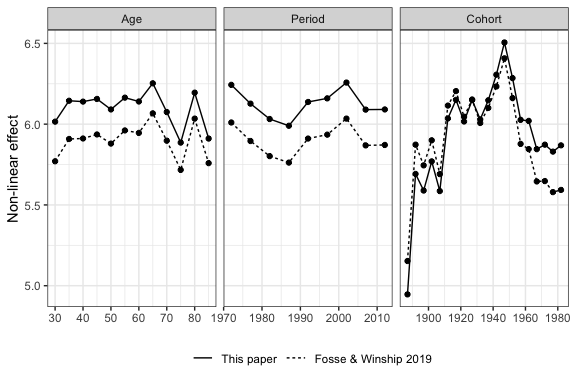

```r
to_plot <- bind_rows(
    get_apc_df(corrected_age, corrected_period, corrected_cohort) %>%
        mutate(which = "This paper"),
    get_apc_df(fw_age, fw_period, fw_cohort) %>%
        mutate(which = "Fosse & Winship 2019")) %>%
    mutate(which = factor(which, levels = c("This paper", "Fosse & Winship 2019")),
        apc = factor(apc, levels = c("Age", "Period", "Cohort")),
        year = as.numeric(year))

# comparison of non-linear effects
p <- to_plot %>%
    ggplot(aes(x = year, y = effect, group = which, linetype = which)) +
    facet_wrap("apc", scales = "free_x") +
    geom_point() + geom_line() +
    labs(y = "Non-linear effect", group = "", linetype = "") +
    theme_bw() +
    theme(legend.position = "bottom", axis.title.x = element_blank())
p
```

## 2D-APC Plot

Fosse and Winship introduced the idea of a 2D-APC plot in their work. These plots are reproduced here for the two sets of results.

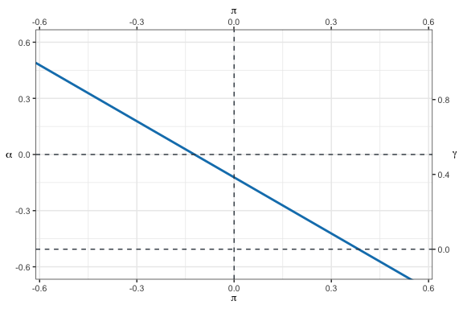

```r
two2d_plot <- function(theta1, theta2) {
    sum_thetas = abs(theta2 - theta1)
    limits = c(-sum_thetas, sum_thetas)

    ggplot() +
        geom_abline(aes(intercept = theta1, slope = -1),
            size = 1, color = "#1080BA") +
        geom_hline(yintercept = 0, linetype = 2, color = "#3C4650") +
        geom_hline(yintercept = -(theta2 - theta1), linetype = 2, color = "#3C4650") +
        geom_vline(xintercept = 0, linetype = 2, color = "#3C4650") +
        scale_y_continuous(expression(alpha),
            limits = limits * 1.2,
            sec.axis = sec_axis(~.+(theta2 - theta1), name = expression(gamma))) +
        scale_x_continuous(expression(pi),
            limits = limits * 1.1,
            sec.axis = dup_axis()) +
        theme_bw() +
        theme(text = element_text(size = 10),
            axis.title.y.left = element_text(angle = 0, vjust = 0.5),
            axis.title.y.right = element_text(angle = 0, vjust = 0.5))
}

two2d_plot(fw_theta1, fw_theta2)
```

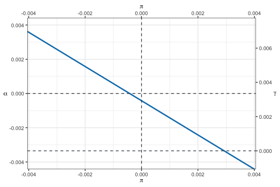

```r
two2d_plot(corrected_theta1, corrected_theta2)
```

## Obtaining smoothed estimates

Orthogonal polynomials can be used as simple smoothers, by simply dropping higher-order polynomial terms. The figure below shows cohort non-linear effects when modeled using different degrees, from low to high. The most complex model will use polynomials of degree 19.

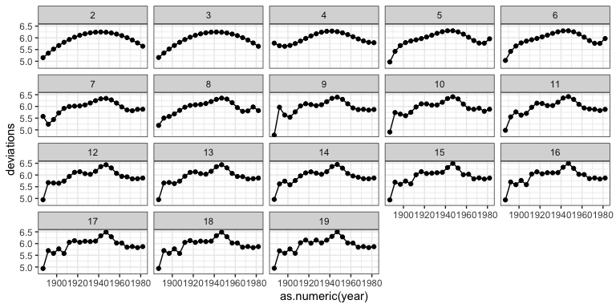

```r
devs <- list()
for (i in seq(ncol(contrasts(data_corrected$c)), 3)) {
    contrasts(data_corrected$c)[, i] <- 0
    reduced <- lm(wordsum ~ a + c + p, data = data_corrected)
    devs_i <- get_deviations_w_intercept(reduced, "^c", contrasts(data_corrected$c))
    devs[[i]] <- tibble(degree = i - 1, year = names(devs_i), deviations = devs_i)
}

cohort_by_degree <- bind_rows(devs) %>%
    bind_rows(tibble(degree = ncol(contrasts(data_corrected$c)),
        year = names(corrected_cohort),
        deviations = corrected_cohort)) %>%
    mutate(year = as.numeric(year))

p <- cohort_by_degree %>%
    ggplot(aes(x = as.numeric(year), y = deviations)) +
    facet_wrap("degree") +
    geom_point() + geom_line() +
    theme_bw()
p
```

## Monotonicity constraint for cohort

Smoothed estimates are desirable when monotonicity constraints are specified. We choose here, somewhat arbitrarily, a polynomial of degree 5, and then specify a monotonicity constraint for the total cohort effect. The dashed line shows the minimum total cohort effect under the assumption that it is monotonically increasing.

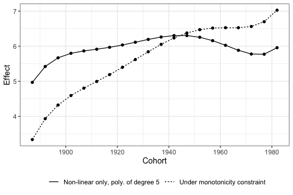

```r
choose_degree <- 5
non_lins <- filter(cohort_by_degree, degree == choose_degree)$deviations
min_slope <- -min(diff(non_lins)) / 5
total_cohort <- non_lins + contrasts(data_corrected$c)[, 1] * min_slope

cohort_df <- filter(cohort_by_degree, degree == choose_degree) %>%
    transmute(effect = deviations,
        year,
        which = paste0("Non-linear only, poly. of degree ", degree)) %>%
    bind_rows(tibble(effect = total_cohort,
        year = as.numeric(names(total_cohort)),
        which = "Under monotonicity constraint"))

p <- cohort_df %>%
    ggplot(aes(x = year, y = effect, linetype = which)) +
    geom_point() + geom_line() +
    theme_bw() +
    theme(text = element_text(size = 12), legend.position = "bottom") +
    labs(x = "Cohort", y = "Effect", linetype = "")
p
```